# Electron cutout factor model report

This model allows for the prediction of electron cut-out factors from previously measured cutouts. Input data is retrieved from csv files saved at `input/data/*.csv`. These measured cutout factors are then modelled using a smoothing spline. A region is defined which is considered to have sufficent cutout data for prediction. Over this valid region the provided data is used to predict an overall uncertainty for prediction. These results are then output to user friendly csv files.

This is a print out of the code that was run in order to produce the outputs given within this directory.

## Code Overview

The code is broken up into three major sections, code initialisation, primary computations, and finally output data to files. Below is an overview of these sections.

### Code initialisation

- **Required packages** | Loading of the required python packages.
  - Loading packages
  - Package options
- **User parameters** | Importing the user parameters from `input/parameters.csv`.
  - Load
  - Display
- **Input output paths and directories** | Defining the locations where files are loaded from and saved to.
  - Input
  - Output

### Primary computations

- **The cutout data** | The data provided within the particular `input/data/*.csv` file is loaded and displayed.
  - Load data
  - Table of the received data
  - Figure of the received data
- **Creating the fit** | The spline fit is created using scipy's SmoothBivariateSpline function. This fit is created in the space of x = width, y = log2(ratio), z = factor. The data is mirrored through the y axis in order to take into account that width / length is equivalent to length / width.
  - Spline
  - Mirrored form | A figure of the spline represented in its mirrored form against width and log2(aspect ratio).
  - Width and aspect ratio form | A figure of the spline given in the more relevant form against width and aspect ratio.
- **Valid region definitions** | Figures of the valid regions that are used to limit the spline fit.
  - Angle gap
  - Fit give
- **Residuals** | Various representations of the differences between the spline fit and the measured cutout factors.
  - Residuals standard deviation
  - Residuals histogram
  - Residuals scatter plot
  - Residuals table
- **Prediction uncertainty** | Calculation of the uncertainty of prediction. It is achieved by remodelling the spline fit with individual data points removed. The fits ability to predict measured data points, within its valid region, when the fit does not have the information for that point is used to estimate the uncertainty of prediction.
  - Remove data and recalculate fit
  - User defined thresholds
  - Prediction differences table
  - Standard deviation of valid prediction differences
  - Histogram of valid prediction differences

### Output data to files

- **Interpolation table** | Build and save an interpolation table of the spline fit according to the users specifications within `input/parameters.csv`. Interpolation table is saved to the model output directory as `interpolation-table.csv`.
  - User defined grid size
  - Creating the interpolation mesh
  - Save interploation table to csv
- **Requested cutout factors** | Calculate and save the cutouts requested within the corresponding file found at `input/requested-cutouts/*.csv`. Program looks for a file with equivalent name to the loaded data file. The predicted cutout factors are saved to the model output directory as `predicted-cutouts.csv`.
  - File used
  - Loading the requested cutouts
  - Calculating the requested factors
  - Save requested factor outputs to csv

## Code initialisation

### Required packages

Loading of the required python packages

#### Loading packages

```python
# Imports numpy and matplotlib
# Libraries similar to MATLAB / Octave
%pylab inline

# For naming files
import datetime

# For directory and file control
import os

# To find list of csv files
from glob import glob

# To read csv files
import csv

# For the displaying, loading, and saving of tables
import pandas as pd

# To display panda tables as html
from IPython.core.display import display_html

# The interpolation method employed by this model
from scipy.interpolate import SmoothBivariateSpline

# Enables 3D plots within matplotlib
from mpl_toolkits.mplot3d import Axes3D

# Imports the give and gap threshold functions contained within threshold_functions.py
from threshold_functions import *
```

Working on numpy version '1.8.1', your version is:

```python
numpy.version.version
```

```
'1.8.1'
```

Working on scipy version '0.14.0', your version is:

```python
import scipy.version
scipy.version.version
```

```
'0.14.0'
```

Back to top

#### Package options

```python
# Makes the panda tables display no more than 12 columns
# The html output bugs out without this
pd.options.display.max_columns = 12

# Makes all figures have a higher resolution
# Figures were too small without this
pylab.rcParams['savefig.dpi'] = 150
```

Back to top

### User parameters

Importing the user parameters from `/input/parameters.csv`

#### Load

```python
# The file path of the paramters.csv file
parameterFilepath = "../input/parameters.csv"

# Loads the parameters.csv file
reader = csv.reader(open(parameterFilepath),delimiter=',')

# Create a dictionary where the keys are the first column of the csv
# and the values are the corresponding second column
parameters = dict(([x[0],float(x[1])] for x in reader))
```

Back to top

#### Display

```python
# Outputs the contents of the dictionary `parameters`
parameters
```

```
{'ratioInterpResolution': 20.0,
 'figureElev': 30.0,
 'widthInterpResolution': 20.0,
 'gapThreshold': 130.0,
 'figureAzim': -140.0,
 'giveThreshold': 0.2}
```

Back to top

### Input output paths and directories

Defining the locations where files are loaded from and saved to

#### Input

```python
# If this notebook was produced as expected using the `runmodel.py` script
# then the input filepath is stored in the processes environmental variable
inputDataFilepath = os.environ.get('INPUTDATAFILEPATH', -1)

# If this notebook was not produced in the expected manner a dummy filepath is used
# This will print a warning
if inputDataFilepath == -1:
    inputDataFilelist = glob("../input/data/*.csv")
    inputDataFilepath = inputDataFilelist[0]

    print("Warning: input filepath was not retrievable")

# Store the base filename that has been used to run this script
inputDataFilename = os.path.basename(inputDataFilepath)[0:-4]
```

```python
# Display the input file path
inputDataFilepath
```

```
'../input/data/06app06eng.csv'
```

Back to top

#### Output

```python
# If this notebook was produced as expected using the `runmodel.py` script
# then the model output directory is stored in the processes environmental variable
modelOutputDirectory = os.environ.get('MODELOUTPUTDIRECTORY', -1)

# If this notebook was not produced in the expected manner a dummy directory is used
# This will print a warning
if modelOutputDirectory == -1:
    stamp = datetime.datetime.now().strftime("%Y%m%d_%H%M%S")
    inputDataFilename = os.path.basename(inputDataFilepath)[0:-4]
    modelOutputDirectory = "../output/"+stamp+"/"+inputDataFilename

    print("Warning: model output directory was not retrievable")

# Creates the required directory if it does not already exist
if not os.path.exists(modelOutputDirectory):
    os.makedirs(modelOutputDirectory)
```

```python
# Display the model output directory
modelOutputDirectory
```

```
'../output/20140826_151705/06app06eng'
```

Back to top

## Primary computations

### The cutout data

The data provided within the particular `input/data/*.csv` file is loaded and displayed.

#### Load data

```python
# Use pandas to load the csv file
cutoutData = pd.read_csv(inputDataFilepath)

# Define width, length, and factor as the csv columns
# which had that corresponding header
width = cutoutData['width'].values
length = cutoutData['length'].values
factor = cutoutData['factor'].values

# Swap width and length values if order was mistaken
swap = width > length

store = width[swap]
width[swap] = length[swap]
length[swap] = store

# Define the cutout aspect ratio
ratio = width/length
```

Back to top

#### Table of the received data

```python
# Create a pandas table using the width, length, and factor variables
# for the purpose of display
df = pd.DataFrame(transpose([width, length, factor]))

# Label the columns
df.columns = ['width', 'length', 'factor']

# Display the table in html format
display_html(df)
```

|  | width | length | factor |
| --- | --- | --- | --- |
| 0 | 2.80 | 3.80 | 0.952 |
| 1 | 2.80 | 5.40 | 0.974 |
| 2 | 3.05 | 4.20 | 0.984 |
| 3 | 3.00 | 3.90 | 0.954 |
| 4 | 3.10 | 3.60 | 0.938 |
| 5 | 3.20 | 3.30 | 0.939 |
| 6 | 3.20 | 3.50 | 0.952 |
| 7 | 3.25 | 4.15 | 0.970 |
| 8 | 3.30 | 5.80 | 0.973 |
| 9 | 3.40 | 4.10 | 0.975 |
| 10 | 3.40 | 5.30 | 0.979 |
| 11 | 3.40 | 5.80 | 0.987 |
| 12 | 3.45 | 4.25 | 0.983 |
| 13 | 3.45 | 6.00 | 0.992 |
| 14 | 3.50 | 5.30 | 0.982 |
| 15 | 3.70 | 3.70 | 0.965 |
| 16 | 3.70 | 4.30 | 0.981 |
| 17 | 3.70 | 5.40 | 0.992 |
| 18 | 3.70 | 5.70 | 0.996 |
| 19 | 3.75 | 4.70 | 1.001 |
| 20 | 3.75 | 5.20 | 0.982 |
| 21 | 3.80 | 3.80 | 0.978 |
| 22 | 3.80 | 5.10 | 0.987 |
| 23 | 3.90 | 4.60 | 0.976 |
| 24 | 3.90 | 7.10 | 0.999 |
| 25 | 4.00 | 4.00 | 0.984 |
| 26 | 4.20 | 4.20 | 0.988 |
| 27 | 4.20 | 4.30 | 0.987 |
| 28 | 4.30 | 6.10 | 0.996 |
| 29 | 4.40 | 5.05 | 1.002 |
| 30 | 4.50 | 4.90 | 0.999 |
| 31 | 4.55 | 5.00 | 1.000 |
| 32 | 4.60 | 4.65 | 1.007 |
| 33 | 4.60 | 5.50 | 1.005 |
| 34 | 4.70 | 4.90 | 0.998 |
| 35 | 4.90 | 5.15 | 0.999 |
| 36 | 5.35 | 5.85 | 1.002 |

37 rows × 3 columns

Back to top

#### Figure of the received data

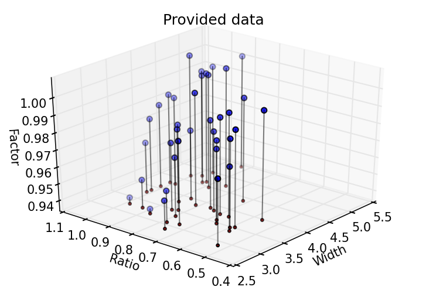

```python
# Create a figure object
fig = plt.figure()

# Add a 3D axis
ax = fig.add_subplot(111, projection='3d')

# Calculate the z axis limits
bot = np.amin(factor) - 0.04 * np.ptp(factor)
top = np.amax(factor) + 0.04 * np.ptp(factor)

# Create a red scatter plot on the bottom plane of the figure
# for visual reference
ax.scatter(width,ratio,bot,c='r',s=5)

# Draw black lines connecting each data point and the bottom plane
# for visual reference
for i in range(len(factor)):
    ax.plot([width[i],width[i]],[ratio[i],ratio[i]],[factor[i],bot],'k',alpha=0.5)

# Scatter plot the 3D data that has been provided
ax.scatter(width,ratio,factor,c='b')

# Define the figure labels
ax.set_xlabel('Width')
ax.set_ylabel('Ratio')
ax.set_zlabel('Factor')

# Define the figure title
ax.set_title('Provided data')

# Enforce the z axis limits previously calculated
ax.set_zlim(bot,top)

# Adjust the viewing angle of the figure to that requested in `parameters.csv`
ax.view_init(elev=parameters['figureElev'], azim=parameters['figureAzim'])
```

Back to top

### Creating the fit

The spline fit is created using scipy's SmoothBivariateSpline function. This fit is created in the space of x = width, y = log2(ratio), z = factor. The data is mirrored through the y axis in order to take into account that width / length is equivalent to length / width.

#### Spline

Mirror the data for spline fitting. This is done so that the full information available is used for the spline fitting around shapes with aspect ratios close to unity.

```python
# Duplicate the width data
widthMirrored = np.append(width,width)

# Mirror the ratio data and take the base 2 log
ratioLogMirrored = np.log2(np.append(width/length,length/width))

# Duplicate the factor data
factorMirrored = np.append(factor,factor)
```

Impliment the spline fit

```python
# Compute the smoothed bivariate spline using the mirrored data
splineFit = SmoothBivariateSpline(widthMirrored,ratioLogMirrored,factorMirrored)

splineFit.ev(array([[1,1],[2,3]]),array([[1,2],[2,5]]))
```

```
array([[ 0.97567927,  0.97567927],
       [ 0.97567927,  0.98457812]])
```

Back to top

#### Mirrored form

A figure of the spline represented in its mirrored form against width and log2(aspect ratio).

```python
# Create vectors of 100 equally spaced values over the data domain
# Domain used is width vs log2(ratio)
xVec1 = linspace(widthMirrored.min(),widthMirrored.max(),100)
yVec1 = linspace(ratioLogMirrored.min(),ratioLogMirrored.max(),100)

# Create a mesh using the vectors created
xMesh1, yMesh1 = meshgrid(xVec1, yVec1)

# Using the angle_gap and fit_give functions defined within `threshold_functions.py`
# to calculate the angle gap and fit give for each width and ratio position
# attempting to be plotted
gapMesh1 = angle_gap(xMesh1,yMesh1,widthMirrored,ratioLogMirrored,1,2)
giveMesh1 = fit_give(xMesh1,yMesh1,widthMirrored,ratioLogMirrored,factorMirrored)

# Use the spline model to predict the cutout factor at each of the meshed postions
zMesh1 = splineFit.ev(xMesh1, yMesh1)

# Find all the positions for which the spline model is above the user defined thresholds
ref1 = (gapMesh1>parameters['gapThreshold']) | (giveMesh1>parameters['giveThreshold'])

# Replace invalid predictions with NaN
zMesh1[ref1] = nan
```

```python
splineFit.ev(xMesh1, yMesh1)
```

```
array([[ 0.97567927,  0.97689785,  0.97809521, ...,  0.97871139,
         0.9773551 ,  0.97596684],
       [ 0.97428918,  0.97550091,  0.97669234, ...,  0.97964685,
         0.97833197,  0.97698518],
       [ 0.97292747,  0.97413249,  0.9753181 , ...,  0.98056322,
         0.9792889 ,  0.97798273],
       ...,
       [ 0.97292747,  0.97413249,  0.9753181 , ...,  0.98056322,
         0.9792889 ,  0.97798273],
       [ 0.97428918,  0.97550091,  0.97669234, ...,  0.97964685,
         0.97833197,  0.97698518],
       [ 0.97567927,  0.97689785,  0.97809521, ...,  0.97871139,
         0.9773551 ,  0.97596684]])
```

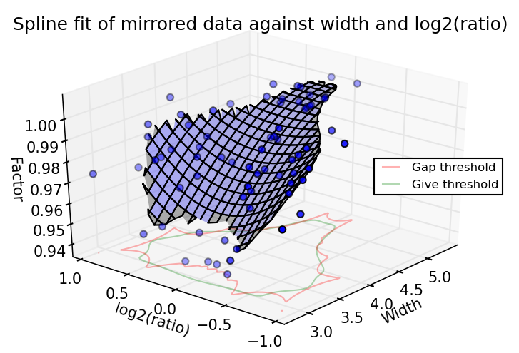

```python
# Create a figure object
fig = plt.figure()

# Create a 3D axis
ax = fig.add_subplot(111, projection='3d')

# Plot contours of the boundaries defined by the give and gap thresholds
ax.contour(xMesh1,yMesh1,gapMesh1, offset=bot, levels=[parameters['gapThreshold']], colors='r',alpha=0.3)
ax.contour(xMesh1,yMesh1,giveMesh1, offset=bot, levels=[parameters['giveThreshold']], colors='g',alpha=0.3)

# Create an undrawn line with the same colour as the contours for the use in the legend
proxyGap, = ax.plot([width.min(),width.min()],[ratioLogMirrored.min(),ratioLogMirrored.min()],[bot,bot],'r-',alpha=0.3)
proxyGive, = ax.plot([width.min(),width.min()],[ratioLogMirrored.min(),ratioLogMirrored.min()],[bot,bot],'g-',alpha=0.3)

# Plot the calculated surface fit
ax.plot_surface(xMesh1,yMesh1,zMesh1,alpha=0.3,rstride=4,cstride=4)

# Plot the measured data
ax.scatter(widthMirrored,ratioLogMirrored,factorMirrored,'b')

# Define axis labels
ax.set_xlabel('Width')
ax.set_ylabel('log2(ratio)')
ax.set_zlabel('Factor')

# Define title
ax.set_title('Spline fit of mirrored data against width and log2(ratio)')

# Enforce the z axis limits
ax.set_zlim(bot,top)

# Adjust the viewing angle of the figure to that requested in `parameters.csv`
ax.view_init(elev=parameters['figureElev'], azim=parameters['figureAzim'])

# Draw the legend using the undrawn lines as proxys for the threshold contours
legend([proxyGap,proxyGive],['Gap threshold', 'Give threshold'],loc=7,prop={'size':8})
```

Back to top

#### Width and aspect ratio form

A figure of the spline given in the more relevant form against width and aspect ratio.

```python
# Create vectors of 100 equally spaced values over the data domain
# Domain used is width vs ratio
xVec2 = linspace(width.min(),width.max(),100)
yVec2 = linspace(ratio.min(),ratio.max(),100)

# Create a mesh using the vectors created
xMesh2, yMesh2 = meshgrid(xVec2, yVec2)

# Using the angle_gap and fit_give functions defined within `threshold_functions.py`
# to calculate the angle gap and fit give for each width and ratio position
# attempting to be plotted
gapMesh2 = angle_gap(xMesh2,log2(yMesh2),widthMirrored,ratioLogMirrored,1,2)
giveMesh2 = fit_give(xMesh2,log2(yMesh2),widthMirrored,ratioLogMirrored,factorMirrored)

# Use the spline model to predict the cutout factor at each of the meshed postions
zMesh2 = splineFit.ev(xMesh2, log2(yMesh2))

# Find all the positions for which the spline model is above the user defined thresholds
ref2 = (gapMesh2>parameters['gapThreshold']) | (giveMesh2>parameters['giveThreshold'])

# Replace invalid predictions with NaN
zMesh2[ref2] = nan
```

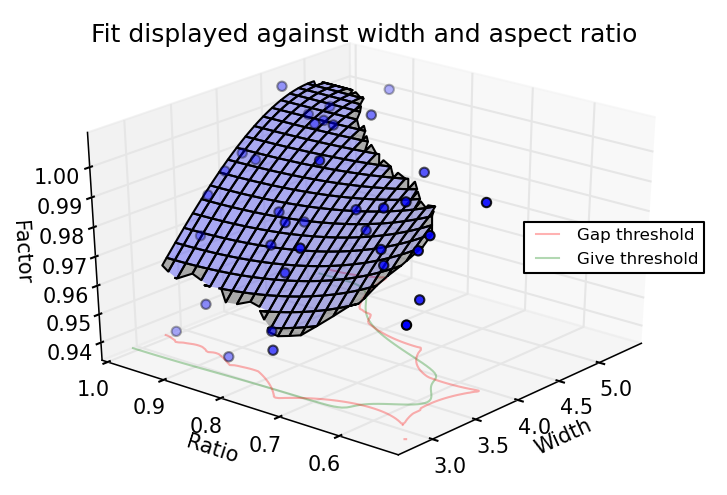

```python
# Create a figure object
fig = plt.figure()

# Create a 3D axis
ax = fig.add_subplot(111, projection='3d')

# Plot contours of the boundaries defined by the give and gap thresholds
ax.contour(xMesh2,yMesh2,gapMesh2, offset=bot, levels=[parameters['gapThreshold']], colors='r',alpha=0.3)
ax.contour(xMesh2,yMesh2,giveMesh2, offset=bot, levels=[parameters['giveThreshold']], colors='g',alpha=0.3)

# Create an undrawn line with the same colour as the contours for the use in the legend
proxyGap, = ax.plot([width.min(),width.min()],[ratio.min(),ratio.min()],[bot,bot],'r-',alpha=0.3)
proxyGive, = ax.plot([width.min(),width.min()],[ratio.min(),ratio.min()],[bot,bot],'g-',alpha=0.3)

# Plot the calculated surface fit
ax.plot_surface(xMesh2,yMesh2,zMesh2,alpha=0.3,rstride=4,cstride=4)

# Plot the measured data
sc = ax.scatter(width,ratio,factor)

# Define axis labels
ax.set_xlabel('Width')
ax.set_ylabel('Ratio')
ax.set_zlabel('Factor')

# Calculate the minimum ratio axis draw
right = ratio.min()-0.01*ratio.ptp()

# Enforce the ratio axis limits
ax.set_ylim(right,1)

# Define title
ax.set_title('Fit displayed against width and aspect ratio')

# Enforce the z axis limits
ax.set_zlim(bot,top)

# Adjust the viewing angle of the figure to that requested in `parameters.csv`
ax.view_init(elev=parameters['figureElev'], azim=parameters['figureAzim'])

# Draw the legend using the undrawn lines as proxys for the threshold contours
legend([proxyGap,proxyGive],['Gap threshold', 'Give threshold'],loc=7,prop={'size':8})
```

Back to top

### Valid region definitions

Figures of the valid regions that are used to limit the spline fit.

#### Angle gap

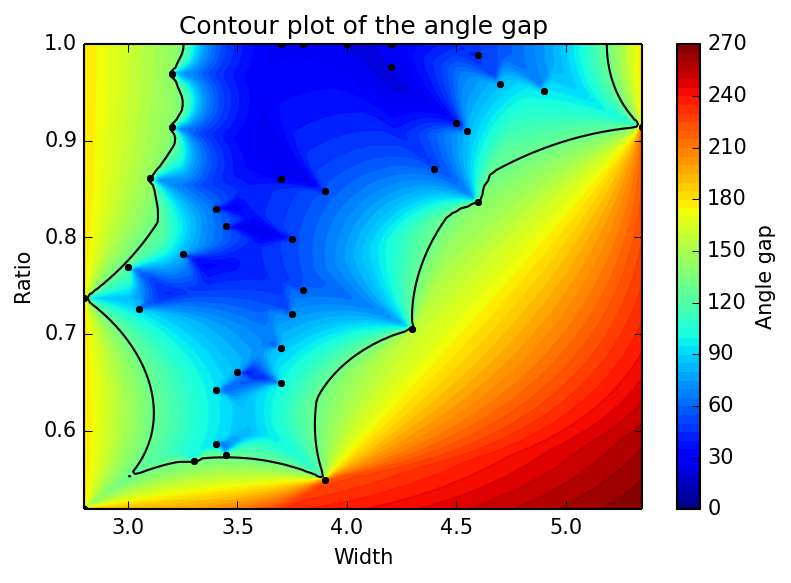

```python
# Create a figure object
fig = plt.figure()

# Create axis object
ax = fig.add_subplot(111)

# Draw the filled in colour contour of the gap mesh calculated prior
cf = ax.contourf(xMesh2,yMesh2,gapMesh2,60)

# Draw a colourbar using the colour fill contour
colorbar(cf, label='Angle gap')

# Draw a normal contour in order better define the colour edge
ax.contour(xMesh2,yMesh2,gapMesh2,60)

# Draw a black contour at the position of the parameter threshold
ax.contour(xMesh2,yMesh2,gapMesh2,levels=[parameters['gapThreshold']],colors='k')

# Plot the positions of the measured data
ax.plot(width,ratio,'k.')

# Define axis labels
ax.set_xlabel('Width')
ax.set_ylabel('Ratio')

# Enforce ratios upper limit of 1
ax.set_ylim(top = 1)

# Define title
ax.set_title('Contour plot of the angle gap')
```

Back to top

#### Fit give

The fit give contour plot given here is especially helpful to work out where best to measure extra cutout factors. New data in regions of high give will help to increase the valid region.

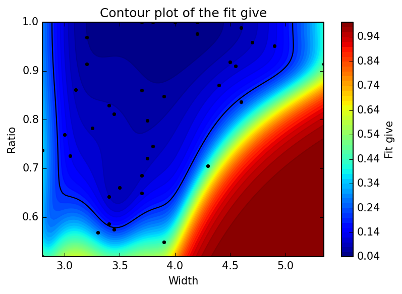

```python
# Create a figure object
fig = plt.figure()

# Create axis object
ax = fig.add_subplot(111)

# Draw the filled in colour contour of the give mesh calculated prior
cf = ax.contourf(xMesh2,yMesh2,giveMesh2,60)

# Draw a colourbar using the colour fill contour
colorbar(cf, label='Fit give')

# Draw a normal contour in order better define the colour edge
ax.contour(xMesh2,yMesh2,giveMesh2,60)

# Draw a black contour at the position of the parameter threshold
ax.contour(xMesh2,yMesh2,giveMesh2,levels=[parameters['giveThreshold']],colors='k')

# Plot the positions of the measured data
ax.plot(width,ratio,'k.')

# Define axis labels
ax.set_xlabel('Width')
ax.set_ylabel('Ratio')

# Enforce ratios upper limit of 1
ax.set_ylim(top = 1)

# Define title
ax.set_title('Contour plot of the fit give')
```

Back to top

### Residuals

Various representations of the differences between the spline fit and the measured cutout factors.

#### Residuals standard deviation

```python
# Calculate the predicted factor for each of the measured points
fitFactors = splineFit.ev(width,log2(ratio))

# Define residuals as the difference between the measured value and the fit value
residuals = fitFactors - factor

# Output the standard deviation of these residuals
std(residuals)
```

```
0.0083839413527253912
```

Back to top

#### Residuals histogram

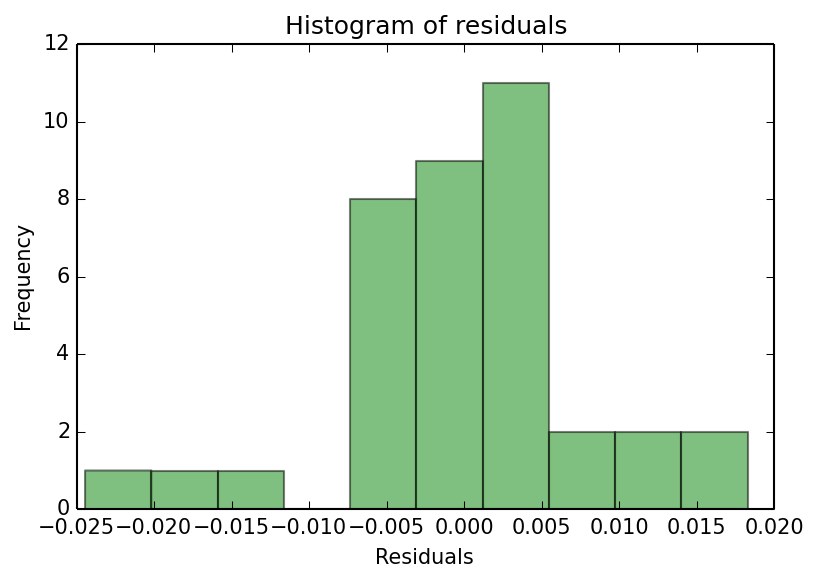

```python
# Create a figure object
fig = plt.figure()

# Create axis object
ax = fig.add_subplot(111)

# Create a histogram of the residuals
n, bins, patches = hist(residuals)

# Change the colour of the histogram to green
setp(patches, 'facecolor', 'g', 'alpha', 0.5)

# Define axis labels
ax.set_xlabel('Residuals')
ax.set_ylabel('Frequency')

# Define title
ax.set_title('Histogram of residuals')
```

Back to top

#### Residuals scatter plot

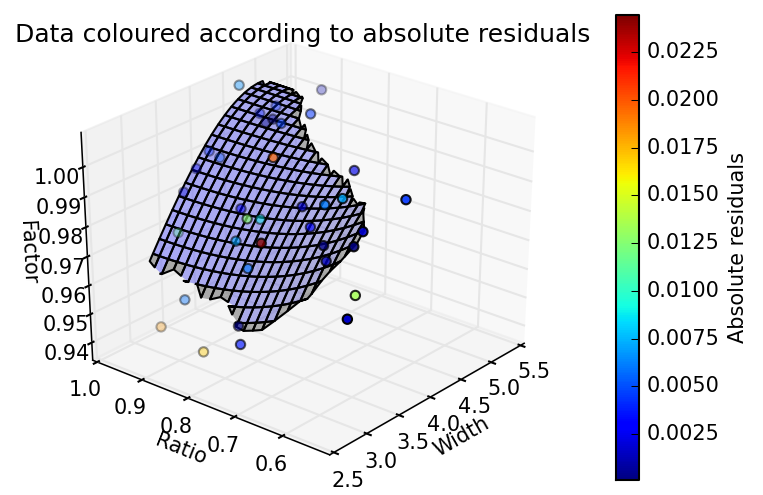

```python
# Create a figure object
fig = plt.figure()

# Create a 3D axis
ax = fig.add_subplot(111, projection='3d')

# Plot the calculated surface fit
ax.plot_surface(xMesh2,yMesh2,zMesh2,alpha=0.3,rstride=4,cstride=4)

# Plot a scatter plot of the measured data with the colour defined
# by that data points absolute residual
sc = ax.scatter(width,ratio,factor,c=abs(residuals))

# Display a colour bar of the residual colours
fig.colorbar(sc, label='Absolute residuals')

# Define axis labels
ax.set_xlabel('Width')
ax.set_ylabel('Ratio')
ax.set_zlabel('Factor')

# Enforce the ratio axis limits
ax.set_ylim(right,1)

# Enforce the z axis limits
ax.set_zlim(bot,top)

# Define title
ax.set_title('Data coloured according to absolute residuals')

# Draw the legend using the undrawn lines as proxys for the threshold contours
ax.view_init(elev=parameters['figureElev'], azim=parameters['figureAzim'])
```

Back to top

#### Residuals table

```python
# Create a pandas table using the width, length, factor, fit factor, residuals, standard deviation
# variables for the purpose of display
df = pd.DataFrame(transpose([width, length, factor, fitFactors, residuals, residuals/std(residuals)]))

# Label the columns
df.columns = ['Width', 'Length', 'Measured Factor', 'Fit Factor', 'Residual', 'Standard deviations']

# Display the table in html format
display_html(df)
```

|  | Width | Length | Measured Factor | Fit Factor | Residual | Standard deviations |
| --- | --- | --- | --- | --- | --- | --- |
| 0 | 2.80 | 3.80 | 0.952 | 0.948438 | -0.003562 | -0.424901 |
| 1 | 2.80 | 5.40 | 0.974 | 0.975679 | 0.001679 | 0.200296 |
| 2 | 3.05 | 4.20 | 0.984 | 0.959546 | -0.024454 | -2.916739 |
| 3 | 3.00 | 3.90 | 0.954 | 0.954750 | 0.000750 | 0.089467 |
| 4 | 3.10 | 3.60 | 0.938 | 0.955002 | 0.017002 | 2.027884 |
| 5 | 3.20 | 3.30 | 0.939 | 0.957302 | 0.018302 | 2.182947 |
| 6 | 3.20 | 3.50 | 0.952 | 0.957875 | 0.005875 | 0.700773 |
| 7 | 3.25 | 4.15 | 0.970 | 0.964030 | -0.005970 | -0.712057 |
| 8 | 3.30 | 5.80 | 0.973 | 0.986443 | 0.013443 | 1.603400 |
| 9 | 3.40 | 4.10 | 0.975 | 0.967879 | -0.007121 | -0.849417 |
| 10 | 3.40 | 5.30 | 0.979 | 0.980336 | 0.001336 | 0.159344 |
| 11 | 3.40 | 5.80 | 0.987 | 0.987115 | 0.000115 | 0.013690 |
| 12 | 3.45 | 4.25 | 0.983 | 0.970409 | -0.012591 | -1.501800 |
| 13 | 3.45 | 6.00 | 0.992 | 0.990235 | -0.001765 | -0.210500 |
| 14 | 3.50 | 5.30 | 0.982 | 0.981767 | -0.000233 | -0.027762 |
| 15 | 3.70 | 3.70 | 0.965 | 0.976445 | 0.011445 | 1.365079 |
| 16 | 3.70 | 4.30 | 0.981 | 0.977937 | -0.003063 | -0.365324 |
| 17 | 3.70 | 5.40 | 0.992 | 0.985890 | -0.006110 | -0.728794 |
| 18 | 3.70 | 5.70 | 0.996 | 0.988784 | -0.007216 | -0.860635 |
| 19 | 3.75 | 4.70 | 1.001 | 0.981463 | -0.019537 | -2.330231 |
| 20 | 3.75 | 5.20 | 0.982 | 0.985027 | 0.003027 | 0.361095 |
| 21 | 3.80 | 3.80 | 0.978 | 0.979940 | 0.001940 | 0.231388 |
| 22 | 3.80 | 5.10 | 0.987 | 0.985252 | -0.001748 | -0.208547 |
| 23 | 3.90 | 4.60 | 0.976 | 0.984803 | 0.008803 | 1.049932 |
| 24 | 3.90 | 7.10 | 0.999 | 1.003414 | 0.004414 | 0.526426 |
| 25 | 4.00 | 4.00 | 0.984 | 0.986426 | 0.002426 | 0.289365 |
| 26 | 4.20 | 4.20 | 0.988 | 0.992110 | 0.004110 | 0.490224 |
| 27 | 4.20 | 4.30 | 0.987 | 0.992131 | 0.005131 | 0.611983 |
| 28 | 4.30 | 6.10 | 0.996 | 0.998345 | 0.002345 | 0.279700 |
| 29 | 4.40 | 5.05 | 1.002 | 0.997278 | -0.004722 | -0.563256 |
| 30 | 4.50 | 4.90 | 0.999 | 0.998905 | -0.000095 | -0.011381 |
| 31 | 4.55 | 5.00 | 1.000 | 0.999762 | -0.000238 | -0.028368 |
| 32 | 4.60 | 4.65 | 1.007 | 1.000450 | -0.006550 | -0.781218 |
| 33 | 4.60 | 5.50 | 1.005 | 1.000691 | -0.004309 | -0.513972 |
| 34 | 4.70 | 4.90 | 0.998 | 1.001789 | 0.003789 | 0.451895 |
| 35 | 4.90 | 5.15 | 0.999 | 1.003397 | 0.004397 | 0.524453 |
| 36 | 5.35 | 5.85 | 1.002 | 1.000957 | -0.001043 | -0.124436 |

37 rows × 6 columns

Back to top

### Prediction uncertainty

Calculation of the uncertainty of prediction. It is achieved by remodelling the spline fit with individual data points removed. The fits ability to predict measured data points, within its valid region, when the fit does not have the information for that point is used to estimate the uncertainty of prediction.

#### Remove data and recalculate fit

```python
# Initialise the predicted factor variable for use in the for loop
predictedFactor = zeros(shape(width))

# Initialise the prediction angle gap variable for use in the for loop
predictionAngleGap = zeros(shape(width))

# Initialise the prediction fit give variable for use in the for loop
predictionFitGive = zeros(shape(width))

# Begin a for loop for each measured cut out factor
for i in range(len(width)):

    # Define the x value for fitting of the point in question
    x = width[i]

    # Define the y value for fitting of the point in question
    y = log2(width[i]/length[i])

    # Create adjusted data sets that are missing the point in question
    adjWidth = np.delete(width,i)
    adjLength = np.delete(length,i)
    adjFactor = np.delete(factor,i)

    # Set up the data in a mirrored fashion in preparation for the spline fit
    adjWidthMirrored = np.append(adjWidth,adjWidth)
    adjRatioLogMirrored = np.log2(np.append(adjWidth/adjLength,adjLength/adjWidth))
    adjFactorMirrored = np.append(adjFactor,adjFactor)

    # Create the adjusted spline fit using the adjusted data sets
    adjSplineFit = SmoothBivariateSpline(adjWidthMirrored,adjRatioLogMirrored,adjFactorMirrored)

    # Evaluate and store the cutout factor of the point in question using the adjust spline fit
    predictedFactor[i] = adjSplineFit.ev(x,y)

    # Evaluate and store the angle gap of the point in question using the adjusted data
    predictionAngleGap[i] = angle_gap(x,y,adjWidthMirrored,adjRatioLogMirrored,1,2)

    # Evaluate and store the fit give of the point in question using the adjusted data
    predictionFitGive[i] = fit_give(x,y,adjWidthMirrored,adjRatioLogMirrored,adjFactorMirrored)
```

Back to top

#### User defined thresholds

In order for a data point to be able to be predicted it needs to be within these user defined tolerances:

```python
# Create a pandas table using the threshold variables for the purpose of display
df = pd.DataFrame([parameters['gapThreshold'], parameters['giveThreshold']])

# Label the rows
df.index = ['Gap', 'Give']

# Label the column
df.columns = ['Threshold']

# Display the table in html format
display_html(df)
```

|  | Threshold |
| --- | --- |
| Gap | 130.0 |
| Give | 0.2 |

2 rows × 1 columns

Back to top

#### Prediction differences table

The prediction of each of the measured data points is given below. Those with an angle gap or fit give higher than the tolerances given above would normally give a result of "nan".

```python
# Calculate the differences between the measured factors and the predicted factors
difference = factor - predictedFactor

# Find the predicted factors that are within the parameter thresholds for their individual fits
withinThresholds = ((predictionAngleGap<parameters['gapThreshold']) &
                    (predictionFitGive<parameters['giveThreshold'])
                    )
```

```python
# Create a pandas table for the purpose of display
df = pd.DataFrame(transpose([width, length, factor, predictedFactor, difference,
                             predictionAngleGap, predictionFitGive, withinThresholds]))

# Label the columns
df.columns = ['Width', 'Length', 'Measured Factor', 'Predicted Factor', 'Difference',
              'Angle Gap', 'Fit Give', 'Within thresholds']

# Display the table in html format
display_html(df)
```

|  | Width | Length | Measured Factor | Predicted Factor | Difference | Angle Gap | Fit Give | Within thresholds |
| --- | --- | --- | --- | --- | --- | --- | --- | --- |
| 0 | 2.80 | 3.80 | 0.952 | 0.945135 | 0.006865 | 180.000000 | 0.615964 | 0 |
| 1 | 2.80 | 5.40 | 0.974 | 1.051417 | -0.077417 | 282.577282 | 0.996449 | 0 |
| 2 | 3.05 | 4.20 | 0.984 | 0.956045 | 0.027955 | 91.920443 | 0.167280 | 1 |
| 3 | 3.00 | 3.90 | 0.954 | 0.954905 | -0.000905 | 124.680699 | 0.180519 | 1 |
| 4 | 3.10 | 3.60 | 0.938 | 0.957777 | -0.019777 | 143.988605 | 0.105176 | 0 |
| 5 | 3.20 | 3.30 | 0.939 | 0.959933 | -0.020933 | 142.396383 | 0.068478 | 0 |
| 6 | 3.20 | 3.50 | 0.952 | 0.958661 | -0.006661 | 139.858275 | 0.074366 | 0 |
| 7 | 3.25 | 4.15 | 0.970 | 0.963534 | 0.006466 | 83.397734 | 0.107332 | 1 |
| 8 | 3.30 | 5.80 | 0.973 | 0.994749 | -0.021749 | 131.384574 | 0.434705 | 0 |
| 9 | 3.40 | 4.10 | 0.975 | 0.967216 | 0.007784 | 62.105660 | 0.088382 | 1 |
| 10 | 3.40 | 5.30 | 0.979 | 0.980492 | -0.001492 | 95.896682 | 0.113223 | 1 |
| 11 | 3.40 | 5.80 | 0.987 | 0.987148 | -0.000148 | 94.401033 | 0.229847 | 0 |
| 12 | 3.45 | 4.25 | 0.983 | 0.969312 | 0.013688 | 58.118148 | 0.090911 | 1 |
| 13 | 3.45 | 6.00 | 0.992 | 0.989683 | 0.002317 | 126.767410 | 0.269689 | 0 |
| 14 | 3.50 | 5.30 | 0.982 | 0.981749 | 0.000251 | 79.664912 | 0.091928 | 1 |
| 15 | 3.70 | 3.70 | 0.965 | 0.977845 | -0.012845 | 28.529588 | 0.057667 | 1 |
| 16 | 3.70 | 4.30 | 0.981 | 0.977636 | 0.003364 | 36.195473 | 0.070345 | 1 |
| 17 | 3.70 | 5.40 | 0.992 | 0.985355 | 0.006645 | 87.293011 | 0.110778 | 1 |
| 18 | 3.70 | 5.70 | 0.996 | 0.987830 | 0.008170 | 100.939949 | 0.142594 | 1 |
| 19 | 3.75 | 4.70 | 1.001 | 0.979962 | 0.021038 | 53.311993 | 0.082306 | 1 |
| 20 | 3.75 | 5.20 | 0.982 | 0.985256 | -0.003256 | 72.790333 | 0.103017 | 1 |
| 21 | 3.80 | 3.80 | 0.978 | 0.980157 | -0.002157 | 28.061896 | 0.052953 | 1 |
| 22 | 3.80 | 5.10 | 0.987 | 0.985125 | 0.001875 | 61.881377 | 0.099879 | 1 |
| 23 | 3.90 | 4.60 | 0.976 | 0.985496 | -0.009496 | 56.515935 | 0.072828 | 1 |
| 24 | 3.90 | 7.10 | 0.999 | 1.016356 | -0.017356 | 222.269409 | 0.879972 | 0 |
| 25 | 4.00 | 4.00 | 0.984 | 0.986655 | -0.002655 | 24.325824 | 0.045110 | 1 |
| 26 | 4.20 | 4.20 | 0.988 | 0.992519 | -0.004519 | 28.362007 | 0.047391 | 1 |
| 27 | 4.20 | 4.30 | 0.987 | 0.992637 | -0.005637 | 25.731008 | 0.049005 | 1 |
| 28 | 4.30 | 6.10 | 0.996 | 1.003007 | -0.007007 | 156.350115 | 0.792759 | 0 |
| 29 | 4.40 | 5.05 | 1.002 | 0.996768 | 0.005232 | 58.475859 | 0.135816 | 1 |
| 30 | 4.50 | 4.90 | 0.999 | 0.998892 | 0.000108 | 39.201511 | 0.107067 | 1 |
| 31 | 4.55 | 5.00 | 1.000 | 0.999730 | 0.000270 | 82.703130 | 0.121627 | 1 |
| 32 | 4.60 | 4.65 | 1.007 | 0.999126 | 0.007874 | 49.530458 | 0.092761 | 1 |
| 33 | 4.60 | 5.50 | 1.005 | 0.998872 | 0.006128 | 138.033065 | 0.286840 | 0 |
| 34 | 4.70 | 4.90 | 0.998 | 1.002629 | -0.004629 | 84.751233 | 0.115301 | 1 |
| 35 | 4.90 | 5.15 | 0.999 | 1.004812 | -0.005812 | 96.262731 | 0.166875 | 1 |
| 36 | 5.35 | 5.85 | 1.002 | 1.000775 | 0.001225 | 255.028956 | 0.905035 | 0 |

37 rows × 8 columns

Back to top

#### Standard deviation of valid prediction differences

The standard deviation of the prediction differences for valid data points is given as the following:

```python
# Print the standard deviation of the valid predicition differences
print("There are", sum(withinThresholds), "points within give and gap thresholds."+
      "\nThe standard deviation of the prediction differences for these is", std(difference[withinThresholds]))
```

```
There are 25 points within give and gap thresholds.
The standard deviation of the prediction differences for these is 0.00891208598357
```

Back to top

#### Histogram of valid prediction differences

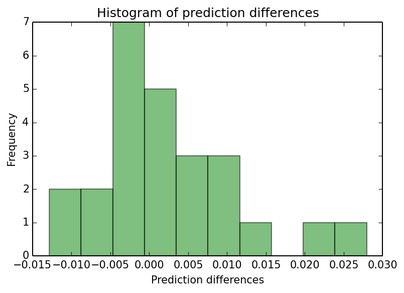

```python
# Create a figure object
fig = plt.figure()

# Create axis object
ax = fig.add_subplot(111)

# Create a histogram of the valid prediction differences
n, bins, patches = hist(difference[withinThresholds])

# Change the colour of the histogram to green
setp(patches, 'facecolor', 'g', 'alpha', 0.5)

# Define axis labels
ax.set_xlabel('Prediction differences')
ax.set_ylabel('Frequency')

# Define title
ax.set_title('Histogram of prediction differences')
```

Back to top

## Output data to files

### Interpolation table

Build and save an interpolation table of the spline fit according to the users specifications within `input/parameters.csv`. Interpolation table is saved to the model output directory as `interpolation-table.csv`.

#### User defined grid size

```python
# Create a pandas table for the purpose of display
df = pd.DataFrame([parameters['widthInterpResolution'], parameters['ratioInterpResolution']])

# Label the rows
df.index = ['Width', 'Ratio']

# Label the column
df.columns = ['Resolutions']

# Display the table in html format
display_html(df)
```

|  | Resolutions |
| --- | --- |
| Width | 20 |
| Ratio | 20 |

2 rows × 1 columns

Back to top

#### Creating the interpolation mesh

```python
# ===========================
#            IDEA
#
# This mesh can be more intelligently created.
# Spread out the steps so that on average each column/row jump has similar cutout effect.
# Could even make it so that the user input is instead, "diff between rows and cols".
#  ^^ This way should work. Use iterative optimisation:
#     maybe scipy.optimize.minimize of
#     `mean((max(columnDiffs) - parameterDiff)**2) + mean((max(rowDiffs) - parameterDiff)**2)`
# ===========================

# Create vectors of values over the data domain. Each data point is rounded to 3 decimal places.
# The number of data points is defined by the user in `input/parameters.csv`.
# Domain used is width vs ratio.
xVec3 = around(linspace(width.min(),width.max(),parameters['widthInterpResolution']),decimals = 3)
yVec3 = around(linspace(ratio.min(),ratio.max(),parameters['ratioInterpResolution']),decimals = 3)

# Create a mesh using the vectors created
xMesh3, yMesh3 = meshgrid(xVec3, yVec3)

# Using the angle_gap and fit_give functions defined within `threshold_functions.py`
# to calculate the angle gap and fit give for each width and ratio mesh
gapMesh3 = angle_gap(xMesh3,log2(yMesh3),widthMirrored,ratioLogMirrored,1,2)
giveMesh3 = fit_give(xMesh3,log2(yMesh3),widthMirrored,ratioLogMirrored,factorMirrored)

# Use the spline model to predict the cutout factor at each of the meshed postions
zMesh3 = splineFit.ev(xMesh3, log2(yMesh3))

# Find all the positions for which the spline model is above the user defined thresholds
ref3 = (gapMesh3>parameters['gapThreshold']) | (giveMesh3>parameters['giveThreshold'])

# Replace invalid predictions with NaN
zMesh3[ref3] = nan
```

```python
# Create a pandas table for the purpose of display and saving
# The data entries of the table are defined by the predicted cutouts in zMesh3
interpDf = pd.DataFrame(zMesh3)

# Label the columns with the width vector
interpDf.columns = xVec3
interpDf.columns.name = 'width'

# Label the rows with the ratio vector
interpDf.index = yVec3
interpDf.index.name = 'ratio'

# Display the table in html format
display_html(interpDf)
```

| width ratio | 2.8 | 2.934 | 3.068 | 3.203 | 3.337 | 3.471 | 3.605 | 3.739 | 3.874 | 4.008 | 4.142 | 4.276 |  |
| --- | --- | --- | --- | --- | --- | --- | --- | --- | --- | --- | --- | --- | --- |
| 0.519 | NaN | NaN | NaN | NaN | NaN | NaN | NaN | NaN | NaN | NaN | NaN | NaN | ... |
| 0.544 | NaN | NaN | NaN | NaN | NaN | NaN | NaN | NaN | NaN | NaN | NaN | NaN | ... |
| 0.569 | NaN | NaN | NaN | NaN | NaN | NaN | NaN | NaN | NaN | NaN | NaN | NaN | ... |
| 0.595 | NaN | NaN | NaN | NaN | 0.983854 | 0.988103 | 0.991880 | NaN | NaN | NaN | NaN | NaN | ... |
| 0.620 | NaN | NaN | NaN | NaN | 0.980634 | 0.985033 | 0.989004 | 0.992519 | NaN | NaN | NaN | NaN | ... |
| 0.645 | NaN | NaN | NaN | 0.972907 | 0.977792 | 0.982322 | 0.986466 | 0.990190 | 0.993484 | NaN | NaN | NaN | ... |
| 0.671 | NaN | NaN | 0.964943 | 0.970229 | 0.975195 | 0.979846 | 0.984147 | 0.988062 | 0.991580 | NaN | NaN | NaN | ... |
| 0.696 | NaN | NaN | 0.962655 | 0.967975 | 0.973010 | 0.977762 | 0.982195 | 0.986271 | 0.989978 | 0.993224 | NaN | NaN | ... |
| 0.721 | NaN | NaN | 0.960656 | 0.966006 | 0.971101 | 0.975942 | 0.980490 | 0.984706 | 0.988578 | 0.992010 | 0.994992 | NaN | ... |
| 0.747 | NaN | NaN | 0.958854 | 0.964232 | 0.969381 | 0.974302 | 0.978954 | 0.983297 | 0.987317 | 0.990916 | 0.994083 | NaN | ... |
| 0.772 | NaN | NaN | 0.957366 | 0.962765 | 0.967959 | 0.972946 | 0.977684 | 0.982131 | 0.986275 | 0.990012 | 0.993331 | 0.996191 | ... |
| 0.797 | NaN | NaN | NaN | 0.961513 | 0.966745 | 0.971788 | 0.976600 | 0.981136 | 0.985385 | 0.989239 | 0.992689 | 0.995691 | ... |
| 0.823 | NaN | NaN | NaN | 0.960417 | 0.965683 | 0.970776 | 0.975651 | 0.980266 | 0.984606 | 0.988564 | 0.992127 | 0.995254 | ... |
| 0.848 | NaN | NaN | NaN | 0.959546 | 0.964838 | 0.969970 | 0.974897 | 0.979574 | 0.983987 | 0.988026 | 0.991681 | 0.994906 | ... |
| 0.873 | NaN | NaN | NaN | 0.958839 | 0.964153 | 0.969317 | 0.974285 | 0.979012 | 0.983484 | 0.987590 | 0.991319 | 0.994623 | ... |
| 0.899 | NaN | NaN | NaN | NaN | 0.963595 | 0.968785 | 0.973787 | 0.978555 | 0.983075 | 0.987236 | 0.991024 | 0.994394 | ... |
| 0.924 | NaN | NaN | NaN | NaN | 0.963196 | 0.968404 | 0.973430 | 0.978228 | 0.982783 | 0.986982 | 0.990813 | 0.994229 | ... |
| 0.949 | NaN | NaN | NaN | NaN | 0.962921 | 0.968142 | 0.973184 | 0.978002 | 0.982581 | 0.986807 | 0.990667 | 0.994116 | ... |
| 0.975 | NaN | NaN | NaN | NaN | 0.962756 | 0.967985 | 0.973037 | 0.977867 | 0.982460 | 0.986702 | 0.990580 | 0.994048 | ... |
| 1.000 | NaN | NaN | NaN | NaN | 0.962706 | 0.967937 | 0.972992 | 0.977826 | 0.982423 | 0.986670 | 0.990553 | 0.994027 | ... |

20 rows × 20 columns

Back to top

#### Save interpolation table to csv

```python
# Define the save path
interpolationTableFilepath = modelOutputDirectory+"/interpolation-table.csv"

# Use pandas to output the table to `interpolation-table.csv`
interpDf.to_csv(interpolationTableFilepath, index_label = 'ratio | width')
```

Back to top

### Requested cutout factors

Calculate and save the cutouts requested within the corresponding file found at `input/requested-cutouts/*.csv`. Program looks for a file with equivalent name to the loaded data file. The predicted cutout factors are saved to the model output directory as `predicted-cutouts.csv`.

#### File used

```python
# Define the location for which to look for the requested cutouts
requestedCutoutFilepath = '../input/requested-cutouts/'+inputDataFilename+'.csv'

# Let the user know whether or not the file has been found
if os.path.isfile(requestedCutoutFilepath):
    print("File found at '"+requestedCutoutFilepath+"'")
else:
    print("No requested cutout file found for "+inputDataFilename+
          "\nLooked for '"+requestedCutoutFilepath+"'")
```

```
File found at '../input/requested-cutouts/06app06eng.csv'
```

Back to top

#### Loading the requested cutouts

```python
# Test if the input file exists
if os.path.isfile(requestedCutoutFilepath):

    # Load the input file using pandas
    requestedCutouts = pd.read_csv(requestedCutoutFilepath)

    # Store the widths and lengths according to the column labels in the file
    reqWidth = requestedCutouts['width'].values
    reqLength = requestedCutouts['length'].values

    # Display the table in html format
    display_html(requestedCutouts)
```

|  | width | length |
| --- | --- | --- |
| 0 | 2.0 | 4.00000 |
| 1 | 3.4 | 3.88888 |

2 rows × 2 columns

Back to top

#### Calculating the requested factors

```python
# Test if the input file exists
if os.path.isfile(requestedCutoutFilepath):


    # Define the x values for fitting
    x = reqWidth

    # Define the y values for fitting
    y = log2(reqWidth/reqLength)

    # Evaluate the predicted cutouts using the spline fit
    predictedCutouts = splineFit.ev(x,y)

    # Evaluate the give and gap parameters
    predictionGap = angle_gap(x,y,widthMirrored,ratioLogMirrored,1,2)
    predictionGive = fit_give(x,y,widthMirrored,ratioLogMirrored,factorMirrored)

    # Test if the requested cutouts go above the user defined thresholds
    ref4 = (predictionGap>parameters['gapThreshold']) | (predictionGive>parameters['giveThreshold'])

    # Replace the cutout prediction with NaN if the threshold is exceeded
    predictedCutouts[ref4] = nan

    # Create a pandas table for the purpose of display and saving
    predictedDf = pd.DataFrame(transpose([reqWidth, reqLength, predictionGap, predictionGive, predictedCutouts]))

    # Label the columns
    predictedDf.columns = ['width', 'length', 'gap', 'give','factor']

    # Display the table in html format
    display_html(predictedDf)
```

|  | width | length | gap | give | factor |
| --- | --- | --- | --- | --- | --- |
| 0 | 2.0 | 4.00000 | 288.688098 | 0.998935 | NaN |
| 1 | 3.4 | 3.88888 | 52.090313 | 0.070832 | 0.966572 |

2 rows × 5 columns

Back to top

#### Save requested factor outputs to csv

```python
# Test if the input file exists
if os.path.isfile(requestedCutoutFilepath):

    # Define the output filepath
    predictedCutoutsFilepath = modelOutputDirectory+"/predicted-cutouts.csv"

    # Use pandas to save the predicted cutouts to `predicted-cutouts.csv`
    predictedDf.to_csv(path_or_buf = predictedCutoutsFilepath, index=False)
```

Back to top